# CM3015: Machine Learning and Neural Networks

```python
stage_5_results.sort_values('val_f1_score', ascending=False)
```

|  | num_hidden_layers | num_units | optimizer | learning_rate | activation_function | batch_size | num_epochs | regularization | val_f1_score |
| --- | --- | --- | --- | --- | --- | --- | --- | --- | --- |
| 0 | 1 | 10 | rmsprop | 0.001 | relu | 128 | 25 | False | 0.599177 |
| 0 | 2 | 10 | rmsprop | 0.001 | relu | 128 | 30 | False | 0.588983 |
| 0 | 1 | 10 | rmsprop | 0.001 | relu | 128 | 30 | False | 0.587181 |
| 0 | 1 | 10 | rmsprop | 0.001 | relu | 128 | 20 | False | 0.571100 |
| 0 | 0 | 10 | rmsprop | 0.001 | relu | 128 | 30 | False | 0.564644 |
| 0 | 2 | 10 | rmsprop | 0.001 | relu | 128 | 25 | False | 0.560880 |
| 0 | 3 | 10 | rmsprop | 0.001 | relu | 128 | 25 | False | 0.548413 |
| 0 | 0 | 10 | rmsprop | 0.001 | relu | 128 | 25 | False | 0.547732 |
| 0 | 1 | 10 | rmsprop | 0.001 | relu | 128 | 15 | False | 0.544056 |
| 0 | 3 | 10 | rmsprop | 0.001 | relu | 128 | 20 | False | 0.542709 |
| 0 | 3 | 10 | rmsprop | 0.001 | relu | 128 | 30 | False | 0.537457 |
| 0 | 2 | 10 | rmsprop | 0.001 | relu | 128 | 20 | False | 0.536040 |
| 0 | 3 | 10 | rmsprop | 0.001 | relu | 128 | 15 | False | 0.529207 |
| 0 | 2 | 10 | rmsprop | 0.001 | relu | 128 | 15 | False | 0.527253 |
| 0 | 0 | 10 | rmsprop | 0.001 | relu | 128 | 20 | False | 0.489171 |
| 0 | 2 | 10 | rmsprop | 0.001 | relu | 128 | 10 | False | 0.483957 |
| 0 | 3 | 10 | rmsprop | 0.001 | relu | 128 | 10 | False | 0.480803 |
| 0 | 0 | 10 | rmsprop | 0.001 | relu | 128 | 15 | False | 0.464227 |
| 0 | 1 | 10 | rmsprop | 0.001 | relu | 128 | 10 | False | 0.455896 |
| 0 | 0 | 10 | rmsprop | 0.001 | relu | 128 | 10 | False | 0.432506 |
| 0 | 1 | 10 | rmsprop | 0.001 | relu | 128 | 5 | False | 0.396564 |
| 0 | 3 | 10 | rmsprop | 0.001 | relu | 128 | 5 | False | 0.378242 |
| 0 | 2 | 10 | rmsprop | 0.001 | relu | 128 | 5 | False | 0.352718 |
| 0 | 0 | 10 | rmsprop | 0.001 | relu | 128 | 5 | False | 0.334771 |

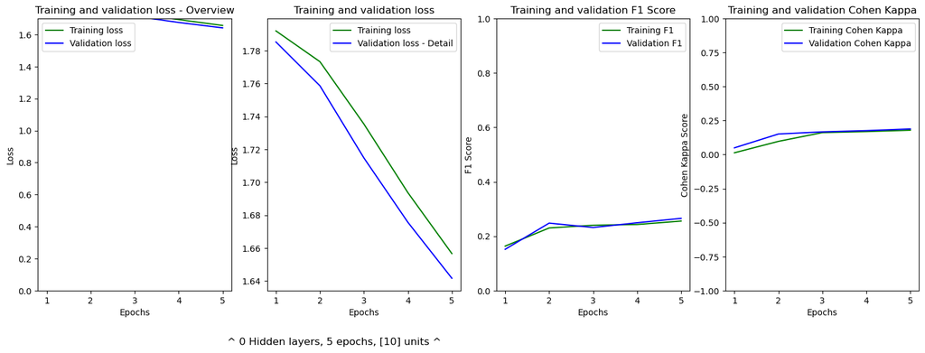

```python
initial_hyperparameters = {
            "optimizer": 'rmsprop',
            "learning_rate": None,
            "batch_size": 128,
            "epochs_number": 5,
            "loss_function": 'categorical_crossentropy',
            #use categorical cross entropy as targets are one-hot encoded
        }
initial_layers = [
    layers.Dense(10, activation='relu', input_shape=(9,)), #input shape == x_train_tensor[0].shape
    layers.Dense(num_classes, activation='softmax') #7 output neurons as there are 7 classes
    ]

model_1 = NeuralNet(initial_layers)
model_1.set_hyperparameters(initial_hyperparameters)
model_1.compile_model()
model_1.fit(x_train_scaled, y_train, (x_val_scaled, y_val), verboseParam=0)
```

Looking at the graphs above, the validation loss is lower than the training loss - this is an unexpected behaviour given that I have not implemented any form of regularisation / dropout yet (Rosebrock, 2019). Author of the O'Reilly book 'Hands-on Machine Learning with Scikit-Learn, Keras & TensorFlow', Aurélien Geron, suggests the following possible cause: 'the training loss is measured during each epoch, whilst the validation loss is measured after each epoch, so on average the training loss is measured 1/2 an epoch earlier.' (Rosebrock, 2019) To further examine this discrepancy between training and validation loss trained the model for 10 epochs:

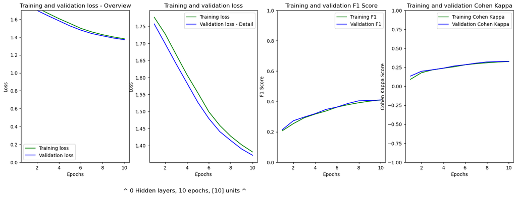

```python
initial_hyperparameters = {
            "optimizer": 'rmsprop',
            "learning_rate": None,
            "batch_size": 128,
            "epochs_number": 10,
            "loss_function": 'categorical_crossentropy',
            #use categorical cross entropy as targets are one-hot encoded
        }
initial_layers = [
    layers.Dense(10, activation='relu', input_shape=(9,)), #input shape == x_train_tensor[0].shape
    layers.Dense(num_classes, activation='softmax') #7 output neurons as there are 7 classes
    ]

model_1 = NeuralNet(initial_layers)
model_1.set_hyperparameters(initial_hyperparameters)
model_1.compile_model()
model_1.fit(x_train_scaled, y_train, (x_val_scaled, y_val), verboseParam=0)
```

The training/validation loss pictured above appears to be congruent with Aurélien Geron's suggestion ; if the training loss were to be shifted 1/2 an epoch to the left [(as Geron suggests)](https://pyimagesearch.com/wp-content/uploads/2019/10/train_val_tweet02.png), the validation loss would no longer be lower than the training loss.

## Identification of a smaller capacity model based:

Based on the, a neural network with 0 hidden layers (consisting of only an input and output layer) is sufficient to beat the statistical baseline identified (F1 Score: 0.25). I decided to further explore if I could identify a smaller capacity model (a model with fewer units) that beats the statistical baseline:

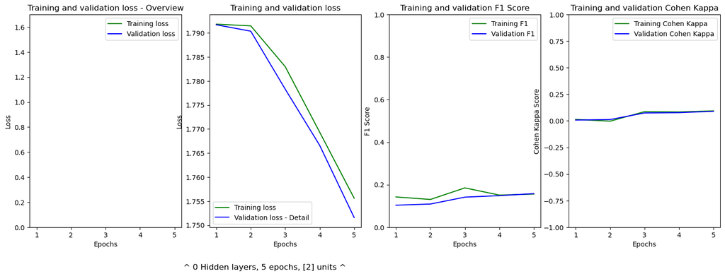

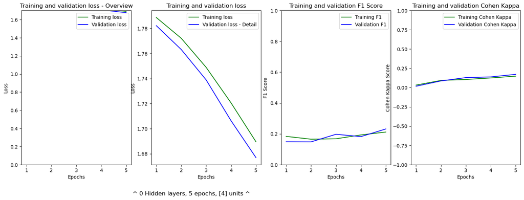

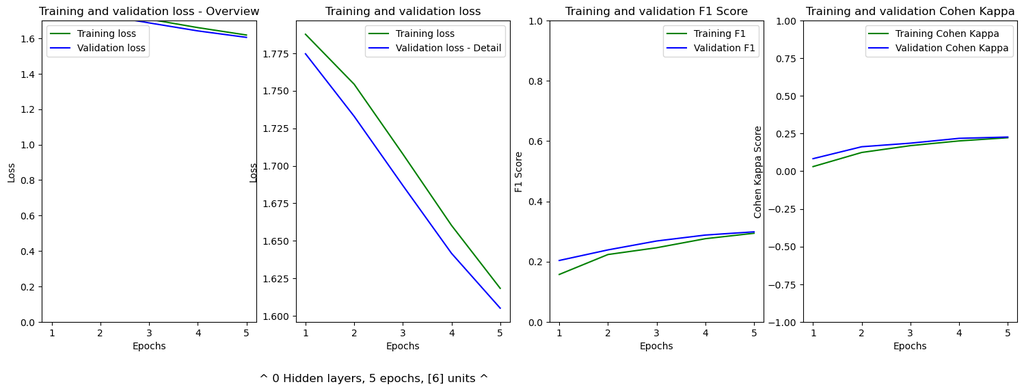

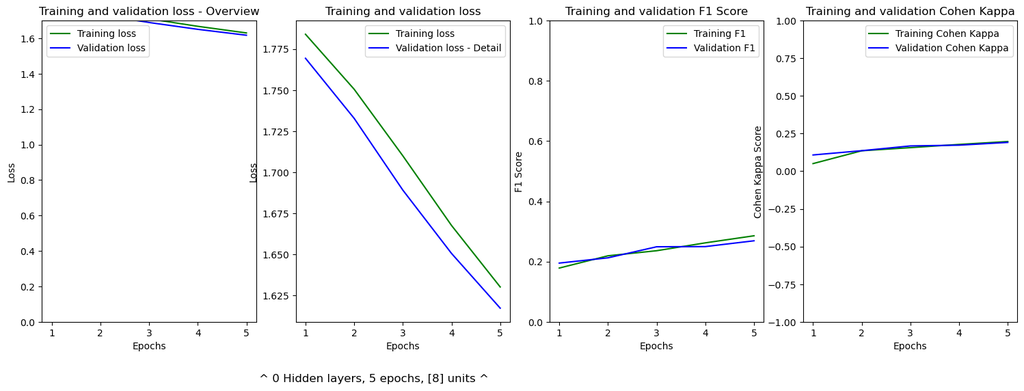

```python
units = [2,4,6,8]
stage_5_results = pd.read_csv('stage_5_results')

for unit in units:
    initial_hyperparameters = {
                "optimizer": 'rmsprop',
                "learning_rate": None,
                "batch_size": 128,
                "epochs_number": 5,
                "loss_function": 'categorical_crossentropy',
                #use categorical cross entropy as targets are one-hot encoded
            }
    initial_layers = [
        layers.Dense(unit, activation='relu', input_shape=(9,)), #input shape == x_train_tensor[0].shape
        layers.Dense(num_classes, activation='softmax') #7 output neurons as there are 7 classes
        ]

    model_1 = NeuralNet(initial_layers)
    model_1.set_hyperparameters(initial_hyperparameters)
    model_1.compile_model()
    model_1.fit(x_train_scaled, y_train, (x_val_scaled, y_val), verboseParam=0)

    results = pd.DataFrame({
                'num_hidden_layers':[len(model_1.model.layers)-2],
                'num_units': unit,
                'optimizer': 'rmsprop',
                'learning_rate': 0.001, #currently using the keras default rmsprop learning rate
                'activation_function': 'relu',
                'batch_size': 128,
                'num_epochs': 5,
                'regularization': False,
                'val_f1_score':[np.mean(model_1.history.history['val_f1_score'][-1])]
            })
    stage_5_results = pd.concat([stage_5_results, results])

stage_5_results.to_csv('stage_5_results', index=False)
```

The shape of the training loss curve indicates underfitting ; the trainig loss is on a trajectory to continue decreasing if training continues. This suggests the model is capable of further learning. (Brownlee, 2019) The training and validation loss are also relatively high at ~1.6 - this also suggests underfitting (Brownlee, 2019).

```python
stage_5_results.sort_values(by='val_f1_score', ascending=True).head()
```

|  | num_hidden_layers | num_units | optimizer | learning_rate | activation_function | batch_size | num_epochs | regularization | val_f1_score |
| --- | --- | --- | --- | --- | --- | --- | --- | --- | --- |
| 0 | 0 | 2 | rmsprop | 0.001 | relu | 128 | 5 | False | 0.157849 |
| 0 | 0 | 4 | rmsprop | 0.001 | relu | 128 | 5 | False | 0.231503 |
| 0 | 0 | 8 | rmsprop | 0.001 | relu | 128 | 5 | False | 0.269033 |
| 0 | 0 | 6 | rmsprop | 0.001 | relu | 128 | 5 | False | 0.298736 |
| 0 | 0 | 10 | rmsprop | 0.001 | relu | 128 | 5 | False | 0.334771 |

```python
np.mean(model_1.model.history.history['val_f1_score'][-1]) #confirm that this model beats the statistical F1 baseline
```

```
0.26734504
```

```python
model_1.model.summary()
```

[output not shown]

```python
underfitting_hyperparameters = {
            "optimizer": 'rmsprop',
            "learning_rate": None,
            "batch_size": 128,
            "epochs_number": 5,
            "loss_function": 'categorical_crossentropy',
            #use categorical cross entropy as targets are one-hot encoded
        }
underfitting_layers = [
    layers.Dense(4, activation='relu', input_shape=(9,)), #input shape == x_train_tensor[0].shape
    layers.Dense(num_classes, activation='softmax') #7 output neurons as there are 7 classes
    ]
```

## Exploring the effect of activation functions of the intial model:

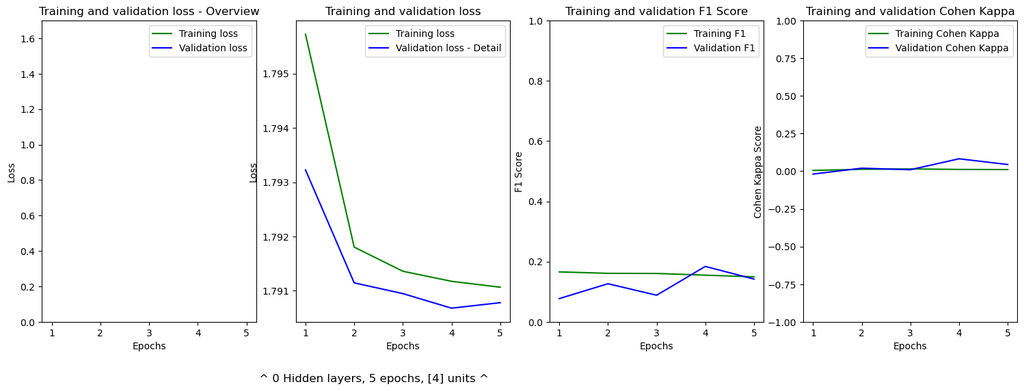

```python
underfitting_layers_no_relu = [
    layers.Dense(4, input_shape=(9,)), #input shape == x_train_tensor[0].shape
    layers.Dense(num_classes, activation='softmax') #7 output neurons as there are 7 classes
    ]

model_1 = NeuralNet(underfitting_layers_no_relu)
model_1.set_hyperparameters(underfitting_hyperparameters)
model_1.compile_model()
model_1.fit(x_train_scaled, y_train, (x_val_scaled, y_val))
```

[the graph on the top left appears blank as the training/validation loss is higher than 1.7 - as shown in the more detailed plot in the second column]

```python
stage_5_results.sort_values('val_f1_score', ascending=False).head()
```

|  | num_hidden_layers | num_units | optimizer | learning_rate | activation_function | batch_size | num_epochs | regularization | val_f1_score |
| --- | --- | --- | --- | --- | --- | --- | --- | --- | --- |
| 21 | 1 | 10 | rmsprop | 0.001 | relu | 128 | 30 | False | 0.634199 |
| 17 | 1 | 10 | rmsprop | 0.001 | relu | 128 | 25 | False | 0.626490 |
| 9 | 1 | 10 | rmsprop | 0.001 | relu | 128 | 15 | False | 0.622296 |
| 15 | 3 | 10 | rmsprop | 0.001 | relu | 128 | 20 | False | 0.617044 |
| 23 | 3 | 10 | rmsprop | 0.001 | relu | 128 | 30 | False | 0.616332 |

The top ranking model had 1 hidden layers and was trained for 30 epochs; this may be a good point of comparison as the model is relatively simple (with only 1 hidden layer and 10 units).

# Step 6: Scaling - Developing a model that overfits

## Section 6 and 7: Table of F1 outcomes:

```python
stage_6_results = pd.read_csv('./stage_6_results')
stage_6_results.sort_values(by='val_f1_score', ascending=False)
```

|  | num_hidden_layers | num_units | optimizer | learning_rate | activation_function | batch_size | num_epochs | regularization | val_f1_score |
| --- | --- | --- | --- | --- | --- | --- | --- | --- | --- |
| 11 | 1 | 600 | rmsprop | 0.001 | relu | 128 | 100 | False | 0.702647 |
| 14 | 1 | 600 | rmsprop | 0.001 | relu | 128 | 100 | L2, alpha:1e-4 | 0.698807 |
| 25 | 4 | 600 | rmsprop | 0.001 | relu | 128 | 100 | False | 0.695391 |
| 19 | 4 | 600 | rmsprop | 0.001 | relu | 128 | 100 | L1, alpha:1e-4 | 0.689719 |
| 22 | 4 | 600 | rmsprop | 0.001 | relu | 128 | 100 | L2, alpha:1e-4 | 0.688726 |
| 24 | 3 | 600 | rmsprop | 0.001 | relu | 128 | 50 | False | 0.688507 |
| 26 | 4 | 600 | rmsprop | 0.001 | relu | 128 | 50 | L1, alpha:1e-4 | 0.680557 |
| 20 | 4 hidden layers (HeNormal Init), 2 Dropout | 600 | rmsprop | 0.001 | relu | 128 | 50 | L1, alpha:1e-6 | 0.677918 |
| 10 | 1 | 600 | rmsprop | 0.001 | relu | 128 | 100 | False | 0.674576 |
| 9 | 1 | 400 | rmsprop | 0.001 | relu | 128 | 200 | False | 0.667377 |
| 8 | 1 | 200 | rmsprop | 0.001 | relu | 128 | 100 | False | 0.662064 |
| 12 | 4 hidden layers (HeUniform Init), 3 Dropout | 600 | rmsprop | 0.001 | relu | 128 | 50 | L1, alpha:1e-6 | 0.661044 |
| 21 | 4 hidden layers (HeNormal Init), 4 Dropout | 600 | rmsprop | 0.001 | relu | 128 | 50 | L1, alpha:1e-6 | 0.656148 |
| 23 | 4 Dense layers, 4 Dropout Layers | 600 | rmsprop | 0.001 | relu | 128 | 50 | L1, alpha:1e-6 | 0.653444 |
| 7 | 1 | 90 | rmsprop | 0.001 | relu | 128 | 200 | False | 0.649796 |
| 13 | 4 hidden layers (HeNormal Init), 4 Dropout | 600 | rmsprop | 0.001 | relu | 128 | 50 | L1, alpha:1e-6 | 0.649669 |
| 15 | 4 hidden layers (HeUniform Init), 3 Dropout | 600 | rmsprop | 0.001 | relu | 128 | 20 | L1, alpha:1e-6 | 0.645878 |
| 17 | 4 hidden layers (HeNormal Init), 3 Dropout | 600 | rmsprop | 0.001 | nadam | 128 | 20 | L1, alpha:1e-6 | 0.644136 |
| 6 | 1 | 90 | rmsprop | 0.001 | relu | 128 | 100 | False | 0.638381 |
| 4 | 0 | 300 | rmsprop | 0.001 | relu | 128 | 50 | False | 0.630724 |
| 3 | 0 | 90 | rmsprop | 0.001 | relu | 128 | 50 | False | 0.618967 |
| 2 | 0 | 70 | rmsprop | 0.001 | relu | 128 | 50 | False | 0.614982 |
| 0 | 0 | 30 | rmsprop | 0.001 | relu | 128 | 50 | False | 0.613648 |
| 16 | 4 hidden layers (HeNormal Init), 3 Dropout | 600 | rmsprop | 0.001 | elu | 128 | 20 | L1, alpha:1e-6 | 0.611494 |
| 1 | 0 | 50 | rmsprop | 0.001 | relu | 128 | 50 | False | 0.607879 |
| 18 | 4 hidden layers (HeNormal Init), 3 Dropout | 600 | adam | 0.001 | relu | 128 | 20 | L1, alpha:1e-6 | 0.588720 |
| 5 | 10 | 90 | rmsprop | 0.001 | relu | 128 | 50 | False | 0.412798 |

## Section 6 Training Log:

In this section I will modify the following 3 hyperparameters in attempt to achieve overfitting:

1. Number of units per layer
2. Number of hidden layers
3. Number of training epochs

As part of this phase I noticed the validation loss was fluctuating / presenting noise:  
I experimented with a learning rate schedule to reduce this noise ; I implemented 'power scheduling' of the learning rate using the 'decay' parameter of tf.keras.optimizer.RMSprop. The decaying learning rate may be beneficial in this context as it may allow the model to search a large / noisy parameter space in the initial stages - and narrow down / reduce of the noise of the hyperparameter space once the correct direction for model weight changes has been identified. (Wang, 2022)

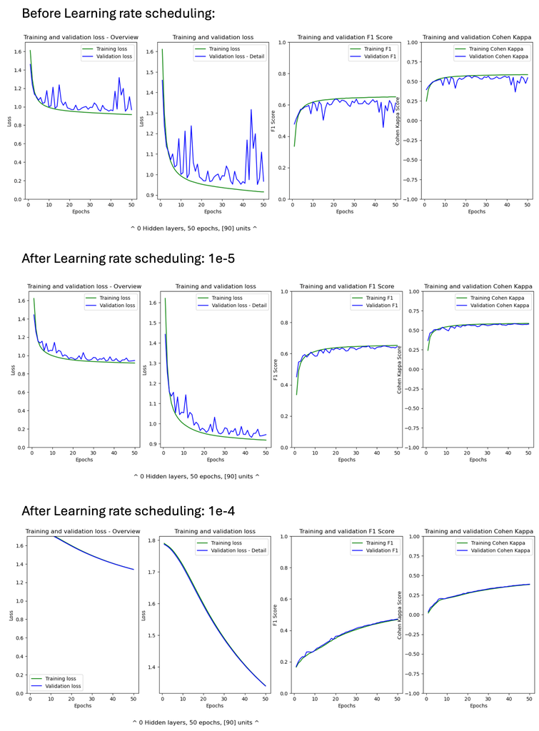

```python
from IPython.display import Image
Image(filename="./images/smoothing_val_loss.png", width='700')
```

I found setting the RMSProp 'decay' to 1e-5 optimal ; this value reduced noise in the validation loss and did not negatively impact the evaluation metrics. [the decay argument of 1e-4 negatively impacted the evalution metrics - with the F1 score decreasing by ~0.2. It also increased the loss by ~0.4]  
I could further experiment with this learning schedule using the 'momentum' parameter

### Element 1: Number of units per layer:

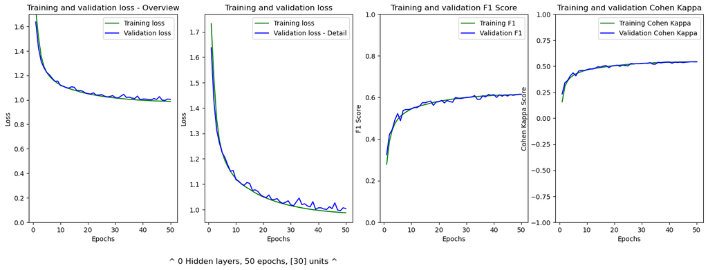

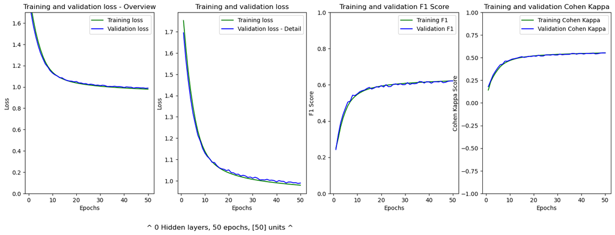

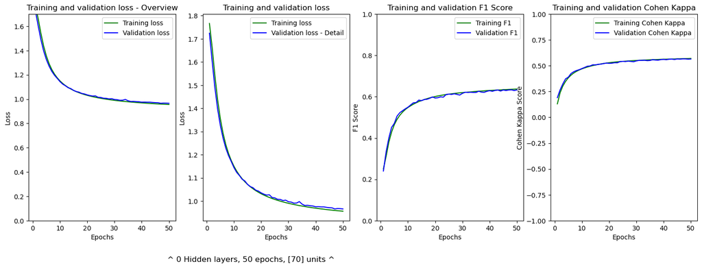

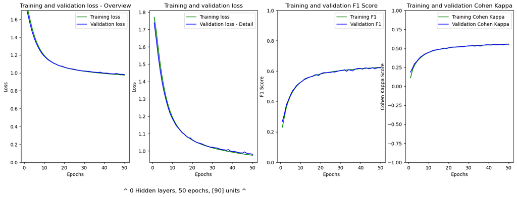

```python
unit_options = [30, 50, 70, 90]
overfitting_hyperparameters = {
            #a tensorflow warning suggested using the legacy version of M1/M2 chips
            "optimizer": tf.keras.optimizers.legacy.RMSprop(decay=1e-5),
            "learning_rate": None,
            "batch_size": 128,
            "epochs_number": 50, #in order to better see the overall patten of loss I have increased the no of epochs
                                    #a better overview may be beneficial when attempting to identify overfitting
            "loss_function": 'categorical_crossentropy'
        }

for unit in unit_options:
    overfitting_layers = [
        layers.Dense(unit, activation='relu', input_shape=(9,)), #input shape == x_train_tensor[0].shape
        layers.Dense(num_classes, activation='softmax') #7 output neurons as there are 7 classes
        ]

    model_2 = NeuralNet(overfitting_layers)
    model_2.set_hyperparameters(overfitting_hyperparameters)
    model_2.compile_model()
    model_2.fit(x_train_scaled, y_train, (x_val_scaled, y_val), verboseParam=0)
```

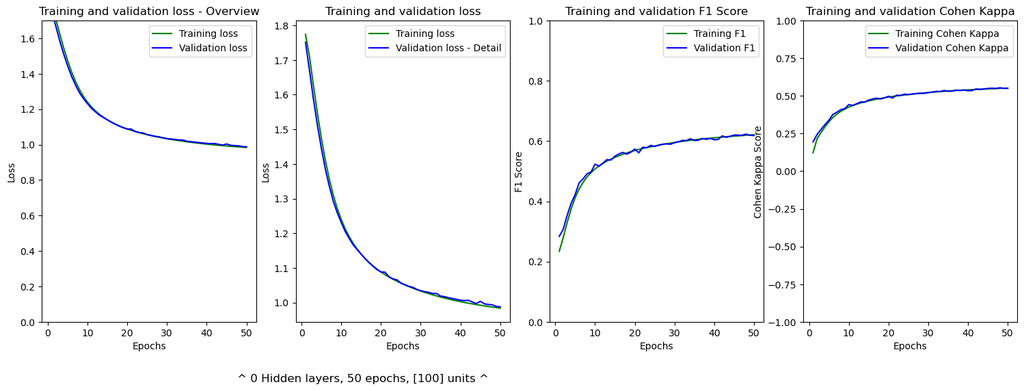

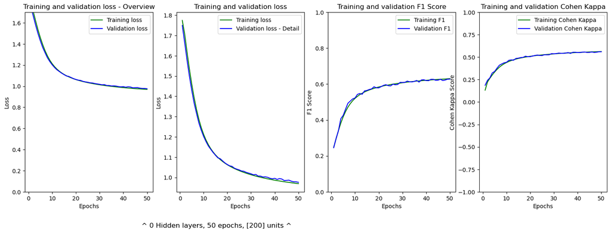

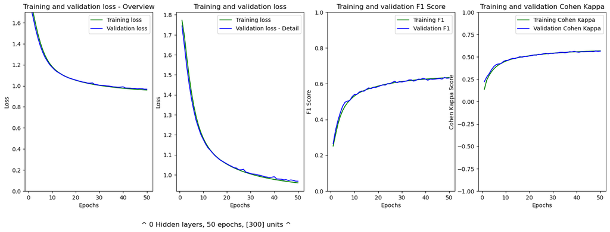

```python
unit_options = [100,200,300]

for unit in unit_options:
    overfitting_layers = [
        layers.Dense(unit, activation='relu', input_shape=(9,)), #input shape == x_train_tensor[0].shape
        layers.Dense(num_classes, activation='softmax') #7 output neurons as there are 7 classes
        ]

    model_2 = NeuralNet(overfitting_layers)
    model_2.set_hyperparameters(overfitting_hyperparameters)
    model_2.compile_model()
    model_2.fit(x_train_scaled, y_train, (x_val_scaled, y_val), verboseParam=0)
```

```python
stage_6_num_units = 90
```

## Element 2: Number of Hidden Layers:

[figure not shown]

[figure not shown]

[figure not shown]

```python
num_hidden_layers = [2, 6, 10]

overfitting_hyperparameters = {
            #a tensorflow warning suggested using the legacy version of M1/M2 chips
            "optimizer": tf.keras.optimizers.legacy.RMSprop(decay=1e-3), #tweaked the rate of decay to best suit this trial
            "learning_rate": None,
            "batch_size": 128,
            "epochs_number": 50,
            "loss_function": 'categorical_crossentropy'
        }
for number in num_hidden_layers:
    layer_trial = [layers.Dense(stage_6_num_units, activation='relu')]*number
    #insert the input layer
    layer_trial.insert(0, layers.Dense(stage_6_num_units, activation='relu', input_shape=(9,)))
    #append the output layer
    layer_trial.append(layers.Dense(num_classes, activation='softmax'))
    model_2 = NeuralNet(layer_trial)
    model_2.set_hyperparameters(overfitting_hyperparameters)
    model_2.compile_model()
    model_2.fit(x_train_scaled, y_train, (x_val_scaled, y_val), verboseParam=0)
```

## Looking at the graphs above, 2 hidden layers resulted in the lowest training/validation loss and the highest evaluation metrics.

## Element 3: Number of Epochs:

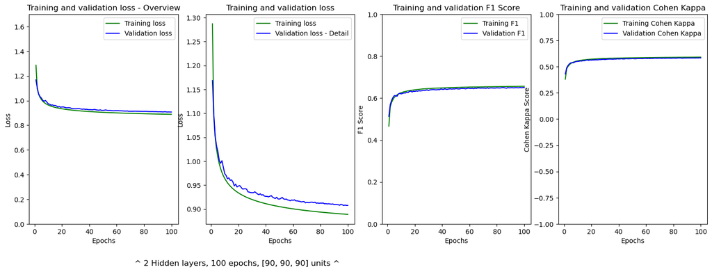

```python
overfitting_hyperparameters = {
            #a tensorflow warning suggested using the legacy version of M1/M2 chips
            "optimizer": tf.keras.optimizers.legacy.RMSprop(decay=1e-3), #tweaked the rate of decay to best suit this trial
            "learning_rate": None,
            "batch_size": 128,
            "epochs_number": 100,
            "loss_function": 'categorical_crossentropy'
        }


overfitting_layers = [
        layers.Dense(stage_6_num_units, activation='relu', input_shape=(9,)), #input shape == x_train_tensor[0].shape
        layers.Dense(stage_6_num_units, activation='relu'),
        layers.Dense(stage_6_num_units, activation='relu'),
        layers.Dense(num_classes, activation='softmax') #7 output neurons as there are 7 classes
        ]

model_2_hidden_layers = NeuralNet(overfitting_layers)
model_2_hidden_layers.set_hyperparameters(overfitting_hyperparameters)
model_2_hidden_layers.compile_model()
model_2_hidden_layers.fit(x_train_scaled, y_train, (x_val_scaled, y_val), verboseParam=0)
```

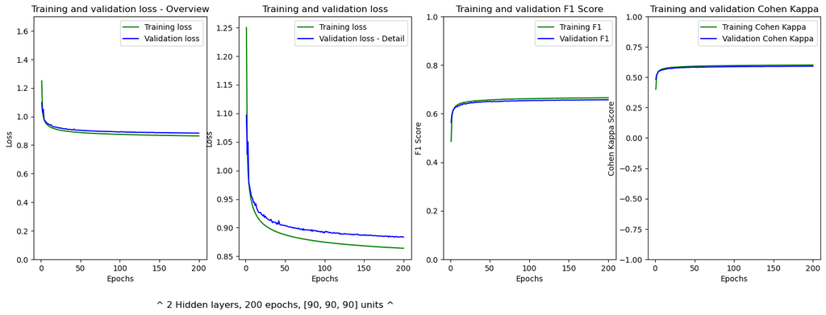

```python
overfitting_hyperparameters = {
            #a tensorflow warning suggested using the legacy version of M1/M2 chips
            "optimizer": tf.keras.optimizers.legacy.RMSprop(decay=1e-3), #tweaked the rate of decay to best suit this trial
            "learning_rate": None,
            "batch_size": 128,
            "epochs_number": 200,
            "loss_function": 'categorical_crossentropy'
        }


overfitting_layers = [
        layers.Dense(stage_6_num_units, activation='relu', input_shape=(9,)), #input shape == x_train_tensor[0].shape
        layers.Dense(stage_6_num_units, activation='relu'),
        layers.Dense(stage_6_num_units, activation='relu'),
        layers.Dense(num_classes, activation='softmax') #7 output neurons as there are 7 classes
        ]

model_2_hidden_layers = NeuralNet(overfitting_layers)
model_2_hidden_layers.set_hyperparameters(overfitting_hyperparameters)
model_2_hidden_layers.compile_model()
model_2_hidden_layers.fit(x_train_scaled, y_train, (x_val_scaled, y_val), verboseParam=0)
```

As the model does not seem to be overfitting (based on the graphs above): I will return to Element 1: Number of units:

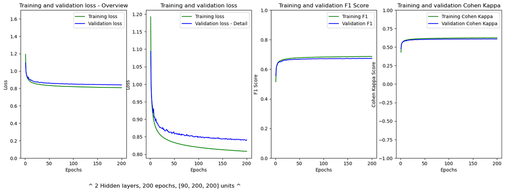

```python
overfitting_hyperparameters = {
            #a tensorflow warning suggested using the legacy version of M1/M2 chips
            "optimizer": tf.keras.optimizers.legacy.RMSprop(decay=1e-3), #tweaked the rate of decay to best suit this trial
            "learning_rate": None,
            "batch_size": 128,
            "epochs_number": 200,
            "loss_function": 'categorical_crossentropy'
        }


overfitting_layers = [
        layers.Dense(stage_6_num_units, activation='relu', input_shape=(9,)), #input shape == x_train_tensor[0].shape
        layers.Dense(200, activation='relu'),
        layers.Dense(200, activation='relu'),
        layers.Dense(num_classes, activation='softmax') #7 output neurons as there are 7 classes
        ]

model_2_hidden_layers = NeuralNet(overfitting_layers)
model_2_hidden_layers.set_hyperparameters(overfitting_hyperparameters)
model_2_hidden_layers.compile_model()
model_2_hidden_layers.fit(x_train_scaled, y_train, (x_val_scaled, y_val), verboseParam=0)
```

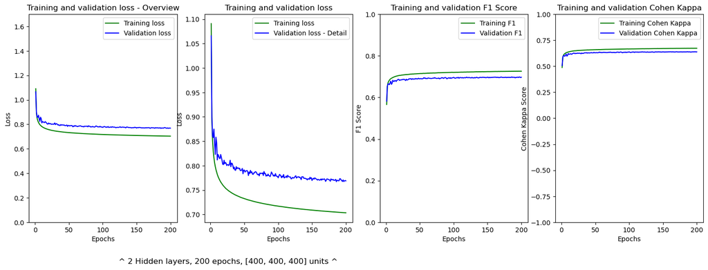

```python
overfitting_hyperparameters = {
            #a tensorflow warning suggested usinaag the legacy version of M1/M2 chips
            "optimizer": tf.keras.optimizers.legacy.RMSprop(decay=1e-3), #tweaked the rate of decay to best suit this trial
            "learning_rate": None,
            "batch_size": 128,
            "epochs_number": 200,
            "loss_function": 'categorical_crossentropy'
        }


overfitting_layers = [
        layers.Dense(400, activation='relu', input_shape=(9,)), #input shape == x_train_tensor[0].shape
        layers.Dense(400, activation='relu'),
        layers.Dense(400, activation='relu'),
        layers.Dense(num_classes, activation='softmax') #7 output neurons as there are 7 classes
        ]

model_2_hidden_layers = NeuralNet(overfitting_layers)
model_2_hidden_layers.set_hyperparameters(overfitting_hyperparameters)
model_2_hidden_layers.compile_model()
model_2_hidden_layers.fit(x_train_scaled, y_train, (x_val_scaled, y_val), verboseParam=0)
```

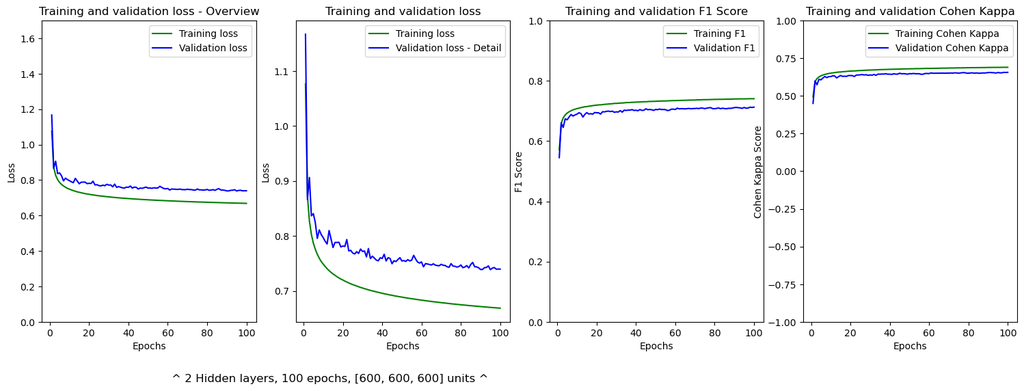

```python
overfitting_hyperparameters = {
            #a tensorflow warning suggested using the legacy version of M1/M2 chips
            "optimizer": tf.keras.optimizers.legacy.RMSprop(decay=1e-3), #tweaked the rate of decay to best suit this trial
            "learning_rate": None,
            "batch_size": 128,
            "epochs_number": 100,
            "loss_function": 'categorical_crossentropy'
        }


overfitting_layers = [
        layers.Dense(600, activation='relu', input_shape=(9,)), #input shape == x_train_tensor[0].shape
        layers.Dense(600, activation='relu'),
        layers.Dense(600, activation='relu'),
        layers.Dense(num_classes, activation='softmax') #7 output neurons as there are 7 classes
        ]

model_2_hidden_layers = NeuralNet(overfitting_layers)
model_2_hidden_layers.set_hyperparameters(overfitting_hyperparameters)
model_2_hidden_layers.compile_model()
model_2_hidden_layers.fit(x_train_scaled, y_train, (x_val_scaled, y_val), verboseParam=0)
```

Increasing the number of units from 400 to 600 has resulted in a slight decrease in the training loss (looking at the y axis of the graphs in the second column in the previous 2 cells)

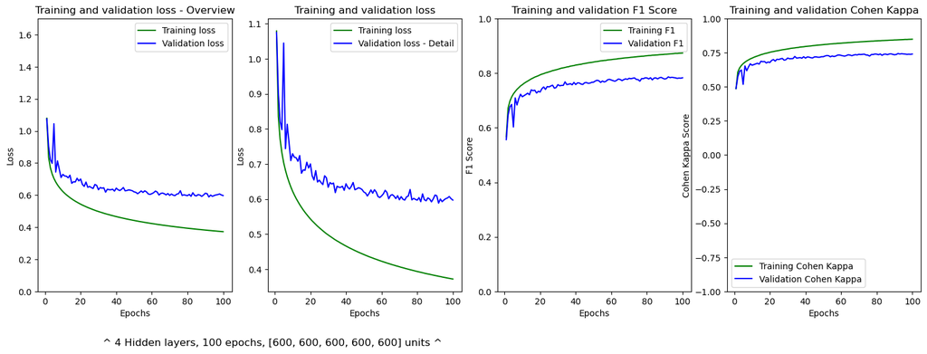

```python
overfitting_hyperparameters = {
            #a tensorflow warning suggested using the legacy version of M1/M2 chips
            "optimizer": tf.keras.optimizers.legacy.RMSprop(decay=1e-3), #tweaked the rate of decay to best suit this trial
            "learning_rate": None,
            "batch_size": 128,
            "epochs_number": 100,
            "loss_function": 'categorical_crossentropy'
        }


overfitting_layers = [
        layers.Dense(600, activation='relu', input_shape=(9,)), #input shape == x_train_tensor[0].shape
        layers.Dense(600, activation='relu'),
        layers.Dense(600, activation='relu'),
        layers.Dense(600, activation='relu'),
        layers.Dense(600, activation='relu'),
        layers.Dense(num_classes, activation='softmax') #7 output neurons as there are 7 classes
        ]

model_2_hidden_layers = NeuralNet(overfitting_layers)
model_2_hidden_layers.set_hyperparameters(overfitting_hyperparameters)
model_2_hidden_layers.compile_model()
model_2_hidden_layers.fit(x_train_scaled, y_train, (x_val_scaled, y_val), verboseParam=0)
```

The combination of 600 units and 4 hidden layers has achieved the lowest training loss and highest evaluation metrics.

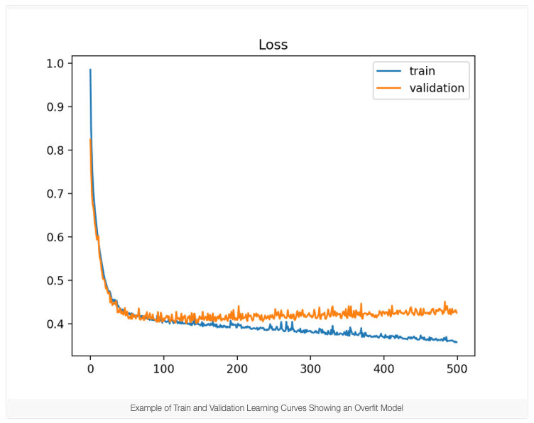

```python
from IPython.display import Image
Image(filename="./images/overfitting_example.png", width='500')
```

Image source: (Brownlee, 2019)

```python
stage_6_hyperparameters = {
            #a tensorflow warning suggested using the legacy version of M1/M2 chips
            "optimizer": tf.keras.optimizers.legacy.RMSprop(decay=1e-3), #tweaked the rate of decay to best suit this trial
            "learning_rate": None,
            "batch_size": 128,
            "epochs_number": 100,
            "loss_function": 'categorical_crossentropy'
        }


stage_6_layers = [
        layers.Dense(600, activation='relu', input_shape=(9,)), #input shape == x_train_tensor[0].shape
        layers.Dense(600, activation='relu'),
        layers.Dense(600, activation='relu'),
        layers.Dense(600, activation='relu'),
        layers.Dense(600, activation='relu'),
        layers.Dense(num_classes, activation='softmax') #7 output neurons as there are 7 classes
        ]

stage_6_num_units = 600
```

# Section 7 Training Log: Model Regularization and hyperparameter tuning (based on validation data performance)

## Model Regularization:

### L1 , L2 Regularization:

It seems that Elastic Net Regularization (L1 and L2 regularization) is generally applied to models with high collinearity or when there are more features than observations. (Mayank, 2023) On examination this dataset does not fit either of these criteria ; there are 9 features and over 1 million observations. A collinearity plot is shown below:

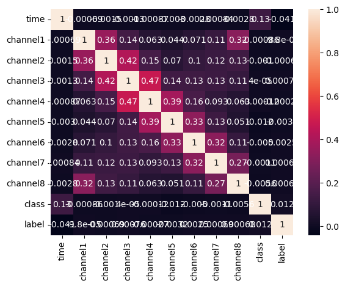

```python
import seaborn as sns
# calculate the correlations using pandas corr() - this method uses the Pearson correlation by default
#Pearsons measures the strength of the linear relationship between 2 variables

featureCorrelations = data.corr()
featureNames = data.columns
#plot the heatmap
sns.heatmap(featureCorrelations, xticklabels=featureNames, yticklabels=featureNames, annot=True)
```

L1/L2 ; weights are incorporated into the loss function, meaning that the model is penalised for large weights

### L2 Regularization:

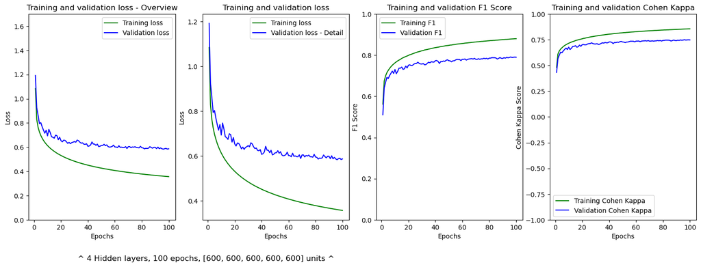

```python
from keras import regularizers
stage_6_hyperparameters = {
            #a tensorflow warning suggested using the legacy version of M1/M2 chips
            "optimizer": tf.keras.optimizers.legacy.RMSprop(decay=1e-3), #tweaked the rate of decay to best suit this trial
            "learning_rate": None,
            "batch_size": 128,
            "epochs_number": 100,
            "loss_function": 'categorical_crossentropy'
        }


stage_6_layers = [
        layers.Dense(stage_6_num_units, activation='relu', input_shape=(9,)), #input shape == x_train_tensor[0].shape
        layers.Dense(stage_6_num_units, activation='relu', bias_regularizer=regularizers.L2(1e-4)),
        layers.Dense(stage_6_num_units, activation='relu', bias_regularizer=regularizers.L2(1e-4)),
        layers.Dense(stage_6_num_units, activation='relu', bias_regularizer=regularizers.L2(1e-4)),
        layers.Dense(stage_6_num_units, activation='relu', bias_regularizer=regularizers.L2(1e-4)),
        layers.Dense(num_classes, activation='softmax') #7 output neurons as there are 7 classes
        ]

model_2_hidden_layers = NeuralNet(stage_6_layers)
model_2_hidden_layers.set_hyperparameters(stage_6_hyperparameters)
model_2_hidden_layers.compile_model()
model_2_hidden_layers.fit(x_train_scaled, y_train, (x_val_scaled, y_val), verboseParam=0)
```

#### L2 Regularization does not appear to have significantly reduce overfitting (at an alpha value of 1e-4)

### L1 Regularization:

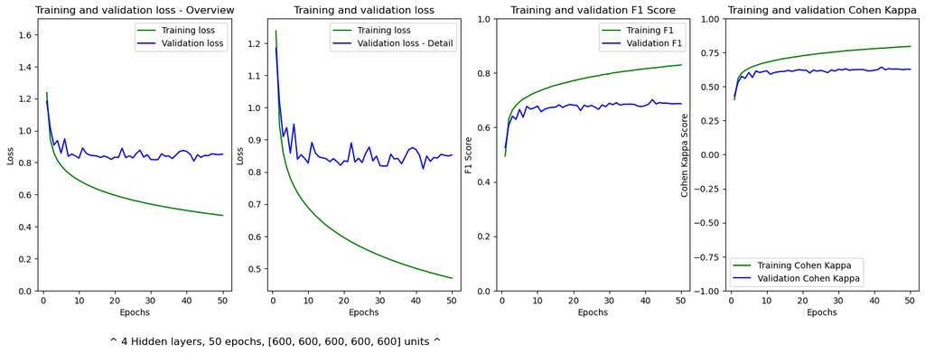

```python
stage_6_hyperparameters = {
            #a tensorflow warning suggested using the legacy version of M1/M2 chips
            "optimizer": tf.keras.optimizers.legacy.RMSprop(decay=1e-3), #tweaked the rate of decay to best suit this trial
            "learning_rate": None,
            "batch_size": 128,
            "epochs_number": 50,
            "loss_function": 'categorical_crossentropy'
        }


stage_6_layers = [
        layers.Dense(600, activation='relu', input_shape=(9,)), #input shape == x_train_tensor[0].shape
        layers.Dense(600, activation='relu', bias_regularizer=regularizers.L1(1e-4)),
        layers.Dense(600, activation='relu', bias_regularizer=regularizers.L1(1e-4)),
        layers.Dense(600, activation='relu', bias_regularizer=regularizers.L1(1e-4)),
        layers.Dense(600, activation='relu', bias_regularizer=regularizers.L1(1e-4)),
        layers.Dense(num_classes, activation='softmax') #7 output neurons as there are 7 classes
        ]

model_2_hidden_layers = NeuralNet(stage_6_layers)
model_2_hidden_layers.set_hyperparameters(stage_6_hyperparameters)
model_2_hidden_layers.compile_model()
model_2_hidden_layers.fit(x_train_scaled, y_train, (x_val_scaled, y_val), verboseParam=0)
```

L1 regularization does not seem to have closed the gap between training and validation loss ; the model still appears to be overfitting.